# Problema 2

Anàlisis de dades 2024-25

Angela Martí, Servio Rivadulla i Jaume Maimó

18/12/2024

# Enunciat del problema

El metabolisme es caracteritza per reaccions químiques vinculades entre si, creant una complexa estructura de xarxa. Una representació simplificada del metabolisme, que anomenem xarxa metabòlica abstracta, és un graf en què les vies metabòliques són nodes i hi ha una aresta entre dos nodes si les corresponents vies comparteixen un o més compostos.

- VH (Vertex histogram).
- SP (Shortest-Path).
- PM (Pyramid Match).

La pràctica consisteix a representar gràficament (amb només 2 coordenades principals) les matrius de similitud generades per cada nucli pintant els punts d’acord amb el grup d’animals d’acord amb el seu phylum.

## Phylum

```
  Animal phylum
1    hsa    101
2    ptr    101
3    pps    101
4    ggo    101
5    pon    101
6    nle    101
7    mcc    101
```

```
[1] 370
```

## Vertex histogram

```
  V1 V2 V3 V4 V5 V6 V7
1  1  1  1  1  1  1  1
2  1  1  1  1  1  1  1
3  1  1  1  1  1  1  1
4  1  1  1  1  1  1  1
5  1  1  1  1  1  1  1
6  1  1  1  1  1  1  1
7  1  1  1  1  1  1  1
```

## Shortest path

```
         V1        V2        V3        V4        V5        V6        V7
1 1.0000000 1.0000000 1.0000000 0.9719029 1.0000000 1.0000000 1.0000000
2 1.0000000 1.0000000 1.0000000 0.9719029 1.0000000 1.0000000 1.0000000
3 1.0000000 1.0000000 1.0000000 0.9719029 1.0000000 1.0000000 1.0000000
4 0.9719029 0.9719029 0.9719029 1.0000000 0.9719029 0.9719029 0.9719029
5 1.0000000 1.0000000 1.0000000 0.9719029 1.0000000 1.0000000 1.0000000
6 1.0000000 1.0000000 1.0000000 0.9719029 1.0000000 1.0000000 1.0000000
7 1.0000000 1.0000000 1.0000000 0.9719029 1.0000000 1.0000000 1.0000000
```

## Pyramid Match

```
        V1       V2       V3       V4       V5       V6       V7
1 1.000000 1.000000 1.000000 0.962963 1.000000 1.000000 1.000000
2 1.000000 1.000000 1.000000 0.962963 1.000000 1.000000 1.000000
3 1.000000 1.000000 1.000000 0.962963 1.000000 1.000000 1.000000
4 0.962963 0.962963 0.962963 1.000000 0.962963 0.962963 0.962963
5 1.000000 1.000000 1.000000 0.962963 1.000000 1.000000 1.000000
6 1.000000 1.000000 1.000000 0.962963 1.000000 1.000000 1.000000
7 1.000000 1.000000 1.000000 0.962963 1.000000 1.000000 1.000000
```

# Objectiu i metodologia

El principal **objectiu** és representar gràficament les matrius de similitud generades per tres tipus de kernels (VH, SP, PM) mitjançant MDS (2D).

**Metodologia**:

1. Carregar dades (matrius de similituds i informació dels phylums).
2. Calcular matrius de distàncies a partir de les similituds.
3. Aplicar escalament multidimensional (MDS).
4. Representar gràficament els resultats.

# Mètode VH

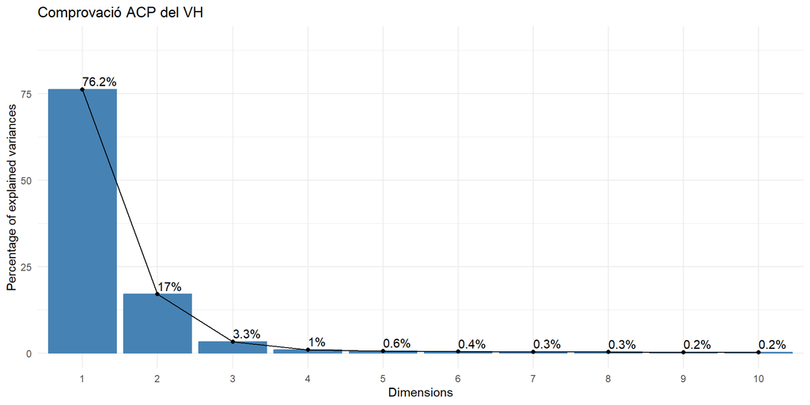

## Gràfic MDS del VH

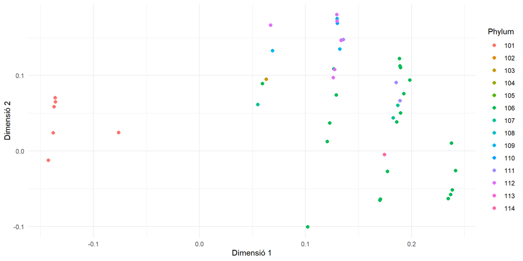

## Gràfic MDS del VH amb perturbació aleatòria

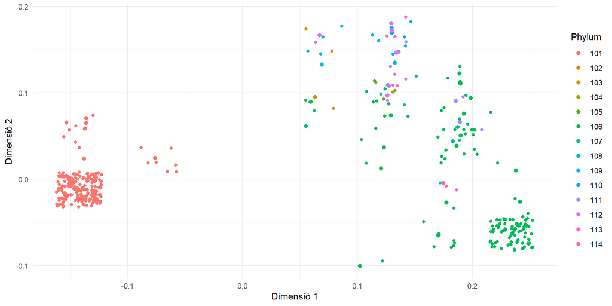

# Métode SP

[figure not shown]

## Gràfic MDS del SP

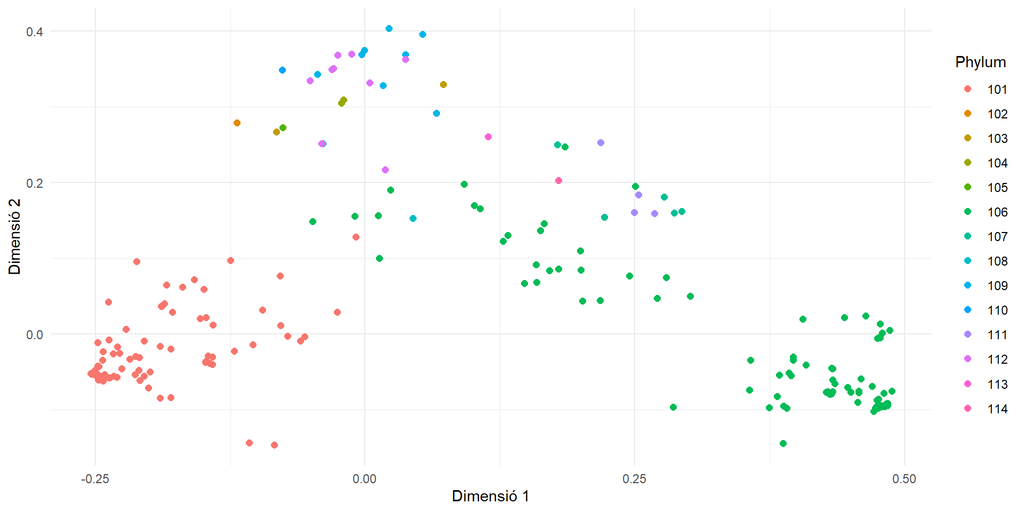

## Gràfic MDS del SP amb perturbació aleatòria

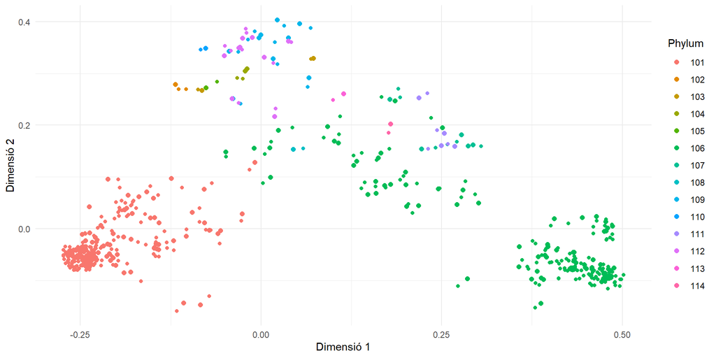

# Métode PM

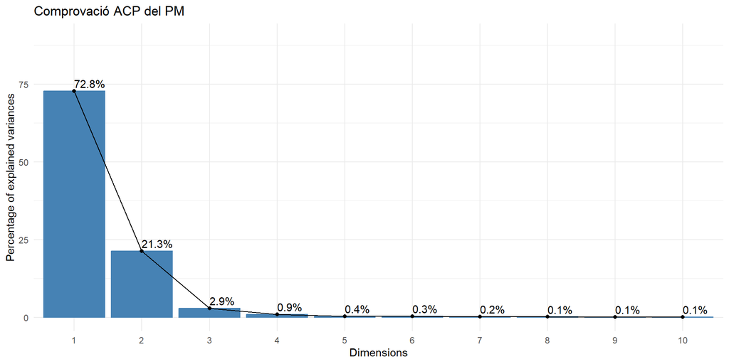

## Gràfic MDS del PM

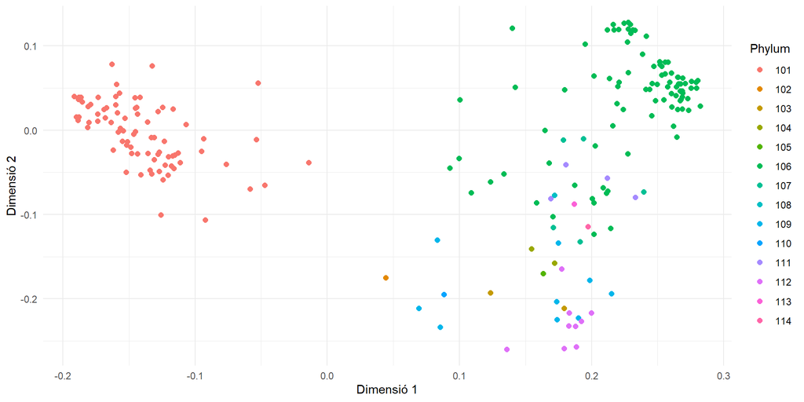

## Conclusions:

- La representació bidimensional no captura tota la informació dels kernels.
- SP i PM són millors que VH per separar grups, però cap mètode és completament efectiu.

### Recomanació:

Explorar altres tècniques de reducció de dimensionalitat o combinar mètodes.

Angela Martí, Servio Rivadulla i Jaume Maimó